# Introductory Statistics in 5 Minutes

May 6, 2019

# *MA-5 in 5 Minutes*

## Basic Statistical Tests in R

- Once the data is loaded, most tests are one line of code.
- Simple graphs are also one-liners (base graphics).

## MA-5 Topics I cover

- One proportion and one mean
- Two proportions and two means (independent samples and paired)
- Multiple proportions ($\chi^2$)
- Multiple means (ANOVA)
- Regression and Correlation
- Multiple linear regression
- MANOVA, Factorial ANOVA, Logistic Regression (optional)
- *Nonparametric Resampling Techniques for all of the above*

## Introduction to Statistical Investigations

- Data and Simulation-Based Applets: http://www.isi-stats.com/isi/applets.html
- Slides from last semester: http://math.westmont.edu/ma5

# *Keep track of notes in RMarkdown*

## **$\Rightarrow$** Make an RMarkdown Document

Let’s keep track of our work in this lesson using RMarkdown.

1. In the *File* menu, choose *New File > RMarkdown…*.
2. In the “New R Markdown” dialog box, give the document a title. Keep the other default settings (Document, HTML).
3. Clicking OK will open a new RMarkdown document with some boilerplate code. *Delete* everything below line 7.
4. *Save* the file to a location and name you will remember. The file name should end in `.Rmd`. (e.g., `introstats.Rmd`)

# *One Sample Tests*

## One-Proportion Test

$$H_0: \pi = 0.5 \\
H_a: \pi \neq 0.5 \\
\hat{p} = 54/83, \quad n=83$$

```r
prop.test(54, 83, p = 0.5)
```

## One-Proportion Test

```r
prop.test(54, 83, p = 0.5)
```

```
##
##  1-sample proportions test with continuity correction
##
## data:  54 out of 83, null probability 0.5
## X-squared = 6.9398, df = 1, p-value = 0.00843
## alternative hypothesis: true p is not equal to 0.5
## 95 percent confidence interval:
##  0.5373112 0.7498063
## sample estimates:
##         p
## 0.6506024
```

## **$\Rightarrow$** Explore the help menus

1. In the console, type `?prop.test`. Read the help menu that appears.
2. Test $H_0: \pi = 0.5$ versus $H_a: \pi > 0.5$ (*one-sided* alternative) for $\hat{p} = 54/83$, $n=83$, *without* the continuity correction.
3. Read about the exact binomial test: `?binom.test`.
4. Repeat the test in #2 using the exact binomial test.

## **$\Rightarrow$** Save your work

5. Above the editor pane for your RMarkdown document, click on the *$^+C$ Insert* button, and choose *R* from the drop down menu. Inside the code chunk that appears, enter the code that worked for steps 1-4.
6. Add some text above or below the code chunk explaining what these commands do.
7. *Knit* and view the HTML output.

## One-Sample $t$-test

```r
sleep <- read.table("http://math.westmont.edu/ma5/classSleep.txt", header = TRUE)
sleep
```

```
##    SleepHours
## 1        6.50
## 2        8.00
## 3        8.50
## 4        6.50
## 5        8.75
## 6        8.00
## 7        8.25
## 8        8.00
## 9        7.50
## 10       7.00
## 11       7.25
## 12       5.00
## 13       7.00
## 14       8.00
```

[output cut: 50 more lines]

## One-Sample $t$-test

$$H_0: \mu = 0 \\
H_a: \mu \neq 0$$

```r
t.test(sleep)
```

## One-Sample $t$-test

```r
t.test(sleep)
```

```
##
##  One Sample t-test
##
## data:  sleep
## t = 44.672, df = 63, p-value < 2.2e-16
## alternative hypothesis: true mean is not equal to 0
## 95 percent confidence interval:
##  6.959264 7.611049
## sample estimates:
## mean of x
##  7.285156
```

## **$\Rightarrow$** Customize the $t$-test

1. Load the data using the following command. (Copy and paste it into the console.)

```r
sleep <- read.table("http://math.westmont.edu/ma5/classSleep.txt", header = TRUE)
```

2. See the help page using `?t.test` in the console.
3. Change the *alternative* hypothesis to $H_a : \mu < 8$ and generate a p-value. Also, generate a *99%* confidence interval.
4. Save your code and make some notes about it in your RMarkdown document.

# *Explanatory/Response Scenarios*

## Explanatory/Response variables

| Explanatory | Response | Scenario/Test |
| --- | --- | --- |
| Categorical (2 levels) | Categorical | two-proportion $z$-test |
| Categorical (2 levels, independent) | Quantitative | two-sample $t$-test |
| Categorical (2 levels, paired) | Quantitative | paired $t$-test |
| Categorical (>2 levels) | Categorical | $\chi^2$ test |
| Categorical (>2 levels) | Quantitative | ANOVA $F$-test |
| Quantitative | Quantitative | Regression/Correlation |

## Two Proportion $z$-test

```r
gilbert <- read.table("http://www.isi-stats.com/isi/data/chap5/Gilbert.txt", header = TRUE)
head(gilbert) # just show the first few lines
```

```
##   GilbertWorked. Patient
## 1            Yes   Death
## 2            Yes   Death
## 3            Yes   Death
## 4            Yes   Death
## 5            Yes   Death
## 6            Yes   Death
```

## Two Proportion $z$-test

```r
table(gilbert)
```

```
##               Patient
## GilbertWorked. Death NoDeath
##            No     34    1350
##            Yes    40     217
```

## Two Proportion $z$-test

There were 34 deaths on the 1384 shifts when Gilbert didn’t work, and 40 deaths on the 257 shifts when she did work.

$$H_0: \pi_1 - \pi_2 = 0 \\
H_a: \pi_1 - \pi_2 \neq 0$$

```r
prop.test(c(34, 40), c(1384, 257))
```

## Two Proportion $z$-test

There were 34 deaths on the 1384 shifts when Gilbert didn’t work, and 40 deaths on the 257 shifts when she did work.

```r
prop.test(c(34, 40), c(1384, 257))
```

```
##
##  2-sample test for equality of proportions with continuity
##  correction
##
## data:  c(34, 40) out of c(1384, 257)
## X-squared = 83.464, df = 1, p-value < 2.2e-16
## alternative hypothesis: two.sided
## 95 percent confidence interval:
##  -0.17844732 -0.08370378
## sample estimates:
##     prop 1     prop 2
## 0.02456647 0.15564202
```

## Two Proportion $z$-test

Instead of giving the counts, you can just send `prop.test` the table:

```r
prop.test(table(gilbert))
```

```
##
##  2-sample test for equality of proportions with continuity
##  correction
##
## data:  table(gilbert)
## X-squared = 83.464, df = 1, p-value < 2.2e-16
## alternative hypothesis: two.sided
## 95 percent confidence interval:
##  -0.17844732 -0.08370378
## sample estimates:
##     prop 1     prop 2
## 0.02456647 0.15564202
```

# *Scenarios using formulas*

## Formulas in R

- Explanatory (x) and response (y) variables are usually denoted using “tilde” notation: `y ~ x`
- Works in different contexts (tests, plots)
- Can also have multiple response, explanatory variables

## Formulas in plots

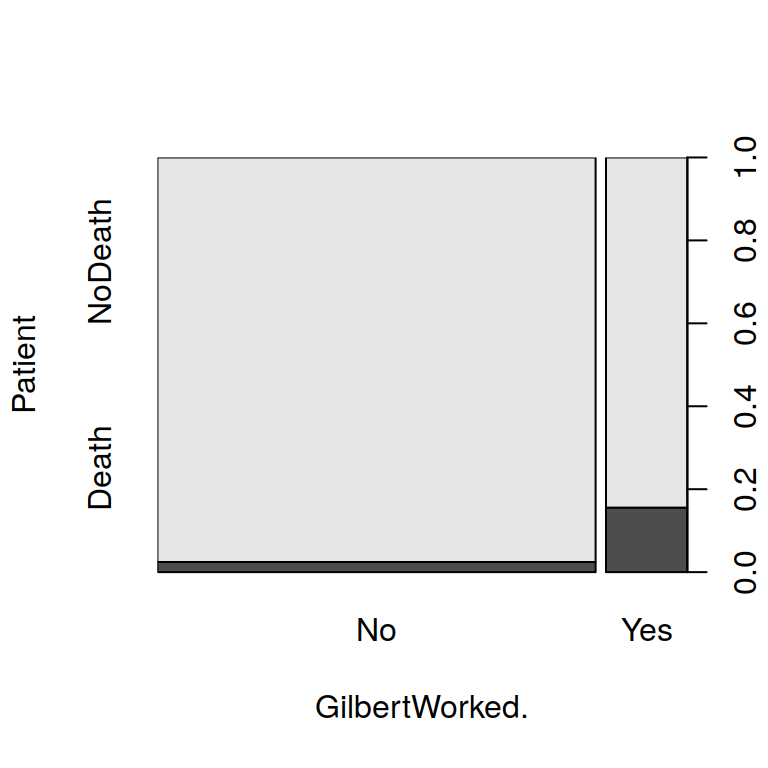

```r
plot(Patient ~ GilbertWorked., data = gilbert)
```

## Two-sample $t$-test

```r
friends <- read.table("http://www.isi-stats.com/isi/data/chap6/CloseFriends.txt", header = TRUE)
summary(friends)
```

```
##     Sex         Friends
##  Men  :654   Min.   :0.000
##  Women:813   1st Qu.:0.000
##              Median :2.000
##              Mean   :1.987
##              3rd Qu.:3.000
##              Max.   :6.000
```

## Two-sample $t$-test

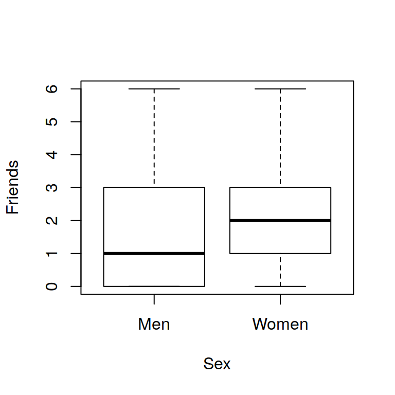

```r
plot(Friends ~ Sex, data = friends)
```

## Two-sample $t$-test

$$H_0: \mu_1 - \mu_2 = 0 \\
H_a: \mu_1 - \mu_2 \neq 0$$

```r
t.test(Friends ~ Sex, data = friends)
```

## Two-sample $t$-test

```r
t.test(Friends ~ Sex, data = friends)
```

```
##
##  Welch Two Sample t-test
##
## data:  Friends by Sex
## t = -2.4497, df = 1392.8, p-value = 0.01442
## alternative hypothesis: true difference in means is not equal to 0
## 95 percent confidence interval:
##  -0.41004255 -0.04536669
## sample estimates:
##   mean in group Men mean in group Women
##            1.860856            2.088561
```

## Paired $t$-test

```r
rounding1st <- read.table("http://www.isi-stats.com/isi/data/chap7/FirstBase.txt", header=TRUE)
summary(rounding1st)
```

```
##      narrow           wide
##  Min.   :5.000   Min.   :4.950
##  1st Qu.:5.463   1st Qu.:5.350
##  Median :5.525   Median :5.450
##  Mean   :5.534   Mean   :5.459
##  3rd Qu.:5.600   3rd Qu.:5.550
##  Max.   :6.300   Max.   :6.250
```

## Paired $t$-test

$$H_0: \mu_d = 0 \\
H_a: \mu_d \neq 0$$

```r
t.test(rounding1st$narrow, rounding1st$wide, paired = TRUE)
```

## Paired $t$-test

```r
t.test(rounding1st$narrow, rounding1st$wide, paired = TRUE)
```

```
##
##  Paired t-test
##
## data:  rounding1st$narrow and rounding1st$wide
## t = 3.9837, df = 21, p-value = 0.0006754
## alternative hypothesis: true difference in means is not equal to 0
## 95 percent confidence interval:
##  0.03584814 0.11415186
## sample estimates:
## mean of the differences
##                   0.075
```

## Chi-square test

```r
apunc <- read.table("http://www.isi-stats.com/isi/data/chap8/Acupuncture.txt", header = TRUE)
table(apunc)
```

```
##           Improvement
## Acupunture Better Not
##       None    106 282
##       Real    184 203
##       Sham    171 216
```

```r
head(apunc)
```

```
##   Acupunture Improvement
## 1       Real      Better
## 2       Real      Better
## 3       Real      Better
## 4       Real      Better
## 5       Real      Better
## 6       Real      Better
```

## Chi-square test

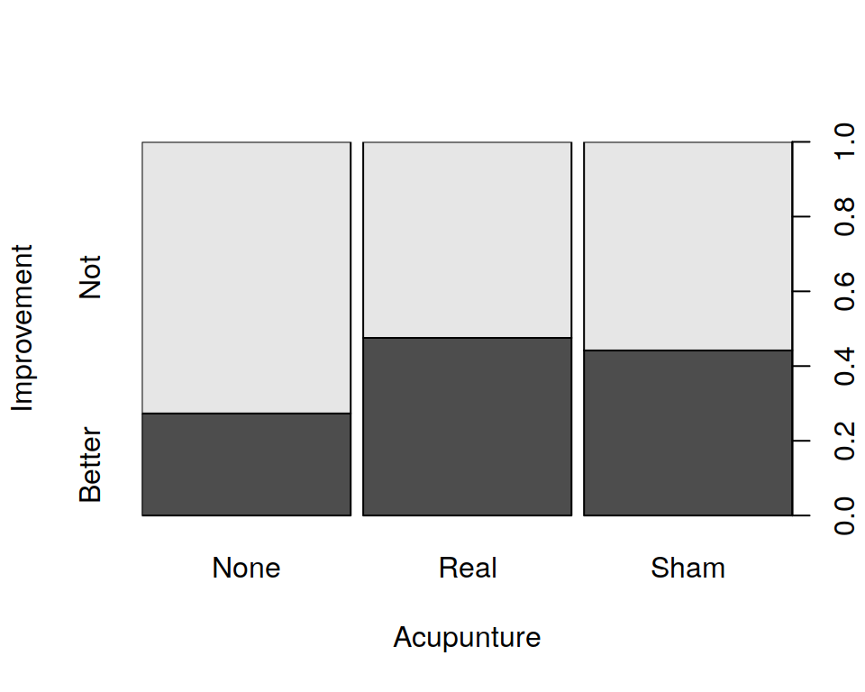

```r
plot(Improvement ~ Acupunture, data = apunc)
```

## Chi-square test

```r
chisq.test(table(apunc))
```

```
##
##  Pearson's Chi-squared test
##
## data:  table(apunc)
## X-squared = 38.054, df = 2, p-value = 5.453e-09
```

## One-way ANOVA

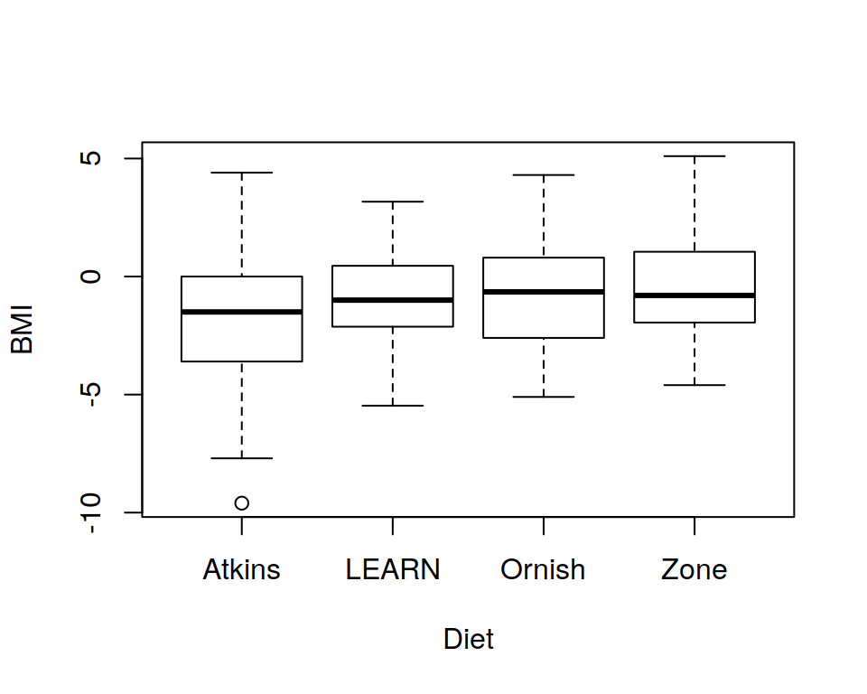

```r
diets <- read.table("http://www.isi-stats.com/isi/data/chap9/Diets.txt", header = TRUE)
plot(BMI ~ Diet, data = diets)
```

## One-way ANOVA

```r
d.aov <- aov(BMI ~ Diet, data = diets)
anova(d.aov)
```

```
## Analysis of Variance Table
##
## Response: BMI
##            Df  Sum Sq Mean Sq F value  Pr(>F)
## Diet        3   54.17 18.0562  3.8001 0.01063 *
## Residuals 307 1458.71  4.7515
## ---
## Signif. codes:  0 '***' 0.001 '**' 0.01 '*' 0.05 '.' 0.1 ' ' 1
```

## Tukey HSD follow-up

```r
TukeyHSD(d.aov)
```

```
##   Tukey multiple comparisons of means
##     95% family-wise confidence level
##
## Fit: aov(formula = BMI ~ Diet, data = diets)
##
## $Diet
##                    diff         lwr      upr     p adj
## LEARN-Atkins  0.7291304 -0.17258536 1.630846 0.1590577
## Ornish-Atkins 0.8809125 -0.02954526 1.791370 0.0619904
## Zone-Atkins   1.1202696  0.21855388 2.021985 0.0079830
## Ornish-LEARN  0.1517821 -0.75293279 1.056497 0.9726913
## Zone-LEARN    0.3911392 -0.50477761 1.287056 0.6726684
## Zone-Ornish   0.2393571 -0.66535784 1.144072 0.9033681
```

## Regression/Corellation

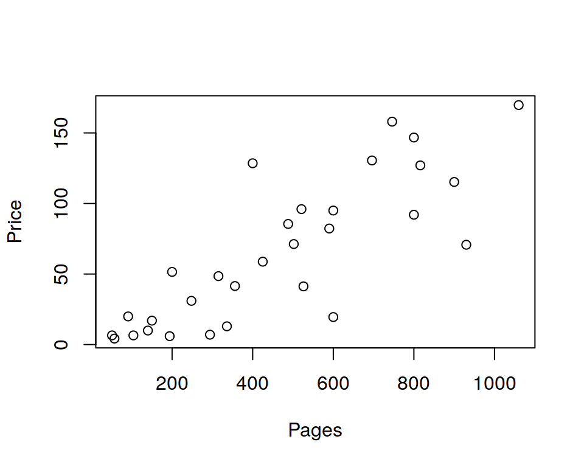

```r
textbooks <- read.table("http://www.isi-stats.com/isi/data/chap10/TextbookPrices.txt", header = TRUE)
plot(Price ~ Pages, data = textbooks)
```

## Regression/Corellation

```r
summary(lm(Price ~ Pages, data = textbooks))
```

```
##
## Call:
## lm(formula = Price ~ Pages, data = textbooks)
##
## Residuals:
##     Min      1Q  Median      3Q     Max
## -65.475 -12.324  -0.584  15.304  72.991
##
## Coefficients:
##             Estimate Std. Error t value Pr(>|t|)
## (Intercept) -3.42231   10.46374  -0.327    0.746
## Pages        0.14733    0.01925   7.653 2.45e-08 ***
## ---
## Signif. codes:  0 '***' 0.001 '**' 0.01 '*' 0.05 '.' 0.1 ' ' 1
##
## Residual standard error: 29.76 on 28 degrees of freedom
## Multiple R-squared:  0.6766, Adjusted R-squared:  0.665
## F-statistic: 58.57 on 1 and 28 DF,  p-value: 2.452e-08
```

## Correlation Matrix

```r
cor(textbooks)
```

```
##           Pages     Price
## Pages 1.0000000 0.8225404
## Price 0.8225404 1.0000000
```

# *Other scenarios*

## UCLA Test Chooser

https://stats.idre.ucla.edu/other/mult-pkg/whatstat/

## **$\Rightarrow$** Breakfast Cereal

**$\Rightarrow$** Do the following in the console, and transfer to your RMarkdown document, or work directly from the RMarkdown document.

1. Load the breakfast cereal data:

```r
cereal <- read.table("http://math.westmont.edu/data/cereal.csv", header=TRUE, sep=";")
```

2. This data set is quite large, so view it by clicking on the *Environment* tab in the upper-right pane, and click on the `cereal` name to see the data as a spreadsheet.
3. Produce a correlation matrix using columns 7, 8, 9, 10, and 16.

## **$\Rightarrow$** Regression

4. Make a scatterplot of `rating` versus `sugar`.
5. Produce a regression table for `rating` as explained by `sugar`.
6. Produce a regression table for `rating` as explained by `fiber`.
7. Produce a regression table for `rating` as explained by `sugar + fiber`. (That’s multiple regression.)

## **$\Rightarrow$** ANOVA

8. We’d like to treat `shelf` as a categorical variable (factor). Do so:

```r
cereal$shelf <- factor(cereal$shelf) # make R treat shelf as categorical
```

9. Produce an ANOVA table for `sugar` as explained by `shelf`. Do a post-hoc test, too.
10. Produce an ANOVA table for `sugar` as explained by `shelf * mfr`. (That’s factorial ANOVA.) Do a post-hoc test, too.

**$\Rightarrow$** If you have been working from the console, save all your code into your RMarkdown document.

# *Tricked-out RMarkdown*

## RMarkdown formatting

RMarkdown supports lots of formatting options. See: https://bookdown.org/yihui/rmarkdown/markdown-syntax.html#block-level-elements

**$\Rightarrow$** Experiment with adding some formattting to your RMarkdown document. Consider adding:

- Headers of different levels
- A bulleted list
- A blockquote

You will have to *Knit* to see what worked.

## Tricked-out HTML

There are lots of HTML options. See: https://bookdown.org/yihui/rmarkdown/html-document.html

**$\Rightarrow$** Experiment with some HTML optons. Try:

- Adding a table of contents.
- A different document theme.